# HJA Dynamic Storage: MLR Updates

## MLR Structure

- Model set 1: watershed characteristics predict storage metrics
  - Selection stepwise AICc + constrained correlated pairs + iterative VIF filtering (VIF <= 10)
  - AICc tie-break for constrained correlated pairs
    - If Ash_Per and lava terms are both retained, test each drop option and keep the model with lowest AICc
    - If Landslide_Total and Landslide_Young are both retained, test both drop options and keep the model with lowest AICc
- Model set 2: storage metrics predict ecological variables
  - Selection constrained predictor sets, then stepwise AICc + iterative VIF filtering (VIF <= 10)
  - Correlated-predictor exclusions are enforced in model fitting; PCA screening is not used
  - Reported coefficients and fit metrics come from the single best model by AICc for each response

## Using Watershed Characteristics to Predict Storage Metrics

- Coefficients shown for this model set are model-averaged across all candidate models with delta AICc <= 2
  - This is used to stabilize inference given low site count and multiple correlated predictors
  - Correlated-pair conflicts are resolved with AICc tie-break before final model averaging
  - r2_adj_best_model below is from the single lowest-AICc model
  - r2_adj_weighted_aicc_lte2 below is Akaike-weighted across all models with delta AICc <= 2
  - Weighting uses weight = exp(-0.5 * delta_AICc) normalized to sum to 1
- Candidate predictor pool for this model set
  - basin_slope
  - Harvest
  - Landslide_Total
  - Landslide_Young
  - Lava1_per
  - Lava2_per
  - Ash_Per
  - Pyro_per

Watershed-characteristics predictors retained across storage responses.

| response | n | predictors_final | r2 | r2_adj_best_model | r2_weighted_aicc_lte2 | r2_adj_weighted_aicc_lte2 | rmse | rmse_loocv | aicc |
| --- | --- | --- | --- | --- | --- | --- | --- | --- | --- |
| RCS_mean | 10 | basin_slope; Landslide_Total; Pyro_per | 0.959 | 0.939 | 0.959 | 0.939 | 0.044160 | 7.963e-02 | -9.019 |
| SD_mean | 10 | basin_slope; Lava2_per | 0.897 | 0.868 | 0.846 | 0.818 | 59.760000 | 1.049e+02 | 126.185 |
| CHS_mean | 7 | Harvest; Landslide_Total | 0.911 | 0.866 | 0.520 | 0.414 | 0.032220 | 4.680e-02 | -0.228 |
| DR_mean | 9 | Pyro_per | 0.846 | 0.824 | 0.846 | 0.824 | 0.009882 | 1.293e-02 | -46.765 |
| Fyw | 6 | Ash_Per | 0.814 | 0.768 | 0.814 | 0.768 | 0.037250 | 6.205e-02 | -4.455 |
| RBI_mean | 10 | Pyro_per | 0.780 | 0.753 | 0.797 | 0.768 | 0.040360 | 4.995e-02 | -25.819 |
| FDC_mean | 10 | Harvest | 0.347 | 0.265 | 0.383 | 0.293 | 0.002527 | 3.039e-03 | -81.237 |
| MTT | 9 | Pyro_per | 0.333 | 0.238 | 0.301 | 0.201 | 0.674700 | 8.528e-01 | 29.258 |
| WB_mean | 10 | basin_slope | 0.238 | 0.143 | 0.279 | 0.174 | 22.860000 | 2.865e+01 | 100.969 |

Watershed model-averaged coefficient file path.

| Predictor | n_responses_retained | mean_abs_beta |
| --- | --- | --- |
| Pyro_per | 4 | 1.033 |
| basin_slope | 3 | 1.323 |
| Harvest | 2 | 1.120 |
| Landslide_Total | 2 | 0.892 |
| Lava2_per | 1 | 0.990 |
| Ash_Per | 1 | 0.902 |

| file |
| --- |
| /Users/sidneybush/Library/CloudStorage/Box-Box/05_Storage_Manuscript/final_workflow/outputs/models/watershed_char_storage_mlr/watershed_char_storage_mlr_model_avg_coef.csv |

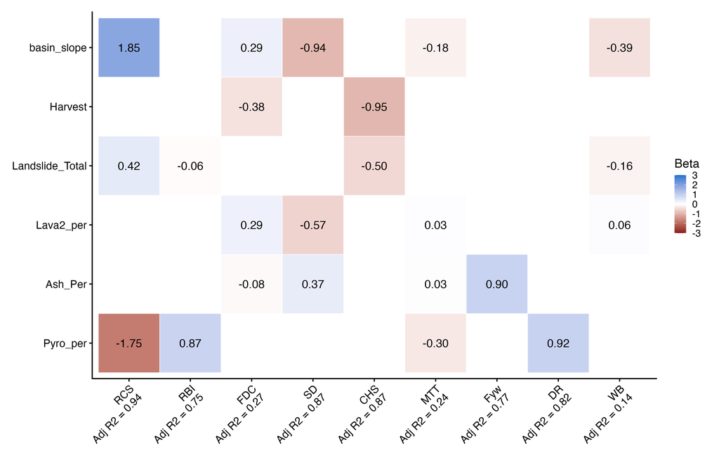

## Using Storage Metrics to Predict Ecological Variables

- Ecological variables modeled
  - T_7DMax: annual maximum 7-day moving-average stream temperature
  - Q_7Q5: 7-day moving-average low-flow statistic (Q5) for discharge
  - T_Q7Q5: mean stream temperature during the annual Q5 7-day low-flow window
- Candidate predictor pool for this model set
  - RCS
  - RBI
  - FDC
  - SD
  - WB
  - CHS
- Predictor inclusion is controlled by complete-case sample size at model fit stage
- Ecological MLR results below are from the single best model by AICc for each response
- Ecological MLR does not use coefficient model averaging

Eco-model best AICc results by site (ordered by adjusted R2, highest to lowest within site).

| site | response | n | predictors_final | r2 | r2_adj | rmse | rmse_loocv | aicc |
| --- | --- | --- | --- | --- | --- | --- | --- | --- |
| WS09 | Q_7Q5 | 22 | SD; WB | 0.49 | 0.436 | 0.02142 | 0.02538 | -96.326 |
| WS10 | Q_7Q5 | 22 | RBI; WB | 0.517 | 0.467 | 0.01639 | 0.01941 | -108.089 |
| WS10 | T_Q7Q5 | 21 | WB | 0.383 | 0.35 | 1.038 | 1.176 | 68.593 |
| WS10 | T_7DMax | 21 | RCS; RBI | 0.385 | 0.316 | 0.4198 | 0.4714 | 33.637 |
| WS01 | Q_7Q5 | 22 | RCS; RBI; SD | 0.772 | 0.734 | 0.01371 | 0.01874 | -112.569 |
| WS01 | T_Q7Q5 | 22 | WB | 0.115 | 0.071 | 1.308 | 1.402 | 81.592 |
| WS01 | T_7DMax | 22 | RCS; RBI; SD; WB | 0.135 | -0.069 | 0.6855 | 0.9713 | 63.42 |
| Look | Q_7Q5 | 21 | RCS; SD | 0.346 | 0.273 | 0.06378 | 0.07219 | -45.503 |
| Look | T_7DMax | 21 | RCS; RBI; SD; WB | 0.105 | -0.119 | 1.033 | 1.414 | 78.948 |
| Look | T_Q7Q5 | 21 | RCS; RBI; SD; WB | 0.039 | -0.201 | 2.65 | 3.432 | 118.529 |
| WS02 | T_7DMax | 22 | RBI; SD; WB | 0.515 | 0.434 | 0.6573 | 0.7954 | 57.723 |
| WS02 | Q_7Q5 | 22 | RCS; RBI; WB | 0.457 | 0.366 | 0.04111 | 0.05248 | -64.239 |
| WS02 | T_Q7Q5 | 22 | SD; WB | 0.148 | 0.058 | 1.434 | 1.668 | 88.633 |
| WS03 | Q_7Q5 | 22 | RBI; WB | 0.37 | 0.303 | 0.04332 | 0.05308 | -65.337 |
| WS03 | T_Q7Q5 | 21 | RCS; WB | 0.257 | 0.175 | 1.132 | 1.359 | 75.318 |
| WS03 | T_7DMax | 21 | RCS; RBI; SD; WB | 0.058 | -0.177 | 0.6494 | 0.8187 | 59.463 |
| Mack | T_7DMax | 21 | RBI | 0.258 | 0.219 | 0.6479 | 0.7361 | 48.781 |
| Mack | Q_7Q5 | 21 | RBI; WB; SD | 0.331 | 0.213 | 0.0468 | 0.0577 | -55.002 |
| Mack | T_Q7Q5 | 21 | RCS | 0.141 | 0.096 | 1.524 | 1.683 | 84.691 |
| WS06 | T_Q7Q5 | 20 | RCS; RBI; SD | 0.435 | 0.329 | 1.59 | 2.186 | 89.599 |
| WS06 | T_7DMax | 22 | RCS; RBI; SD | 0.413 | 0.315 | 0.774 | 0.9369 | 64.913 |
| WS06 | Q_7Q5 | 22 | RCS; SD | 0.277 | 0.201 | 0.02361 | 0.02953 | -92.035 |
| WS07 | Q_7Q5 | 22 | RCS | 0.124 | 0.08 | 0.03213 | 0.03474 | -81.507 |
| WS07 | T_Q7Q5 | 22 | RCS; RBI; SD; WB | 0.162 | -0.035 | 0.796 | 1.073 | 69.992 |
| WS07 | T_7DMax | 22 | RCS; RBI; SD; WB | 0.086 | -0.129 | 0.4317 | 0.5544 | 43.077 |
| WS08 | Q_7Q5 | 22 | RCS; SD; WB | 0.517 | 0.437 | 0.01933 | 0.02503 | -97.434 |
| WS08 | T_7DMax | 22 | RBI; SD; WB | 0.299 | 0.182 | 0.5394 | 0.6785 | 49.026 |
| WS08 | T_Q7Q5 | 22 | SD | 0.128 | 0.084 | 1.757 | 1.884 | 94.566 |

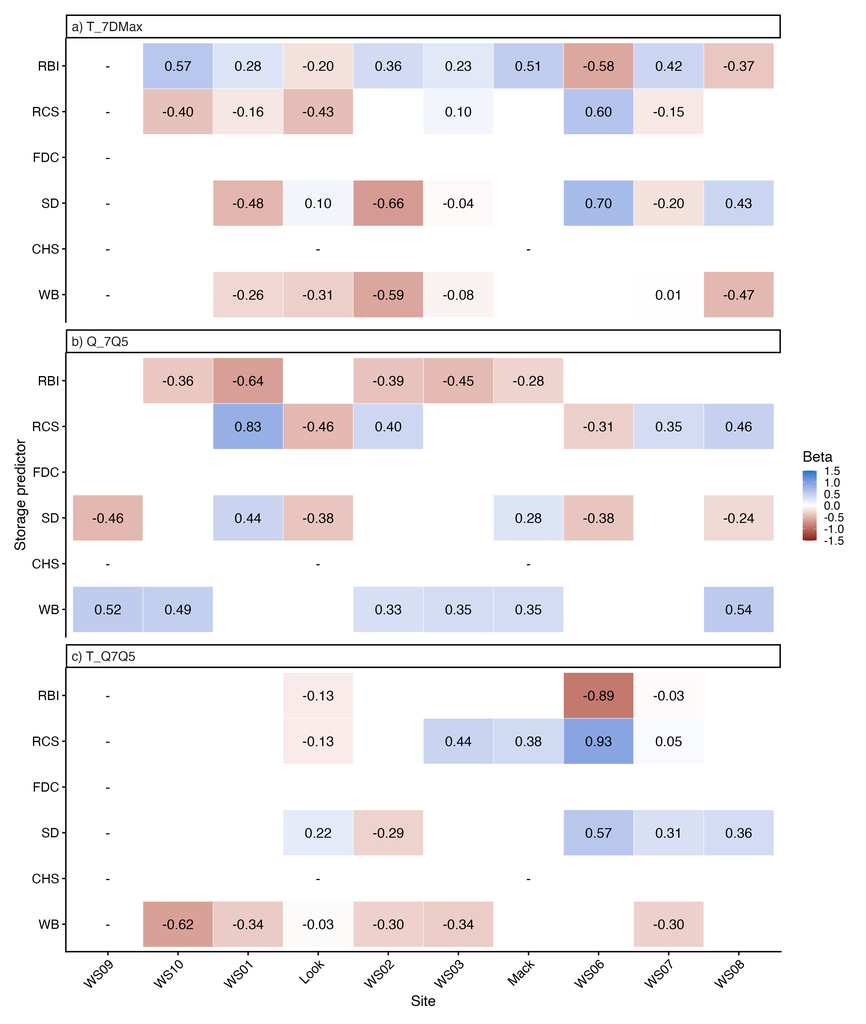

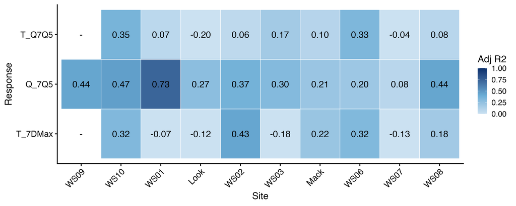

AICc < 2 candidate models (storage to ecological variables)

AICc < 2 eco-candidate table output path.

| file |
| --- |
| /Users/sidneybush/Library/CloudStorage/Box-Box/05_Storage_Manuscript/final_workflow/outputs/tables/mlr/storage_ecovar_mlr_aicc_lt2.csv |

## Model screening

### Watershed model

Watershed-characteristics predictors retained across storage responses.

[output not shown]

### Eco model

Eco-model screening now uses constrained predictor sets, stepwise AICc, VIF checks, and correlated-predictor exclusions; PCA screening is not used.

## LOOCV Validation

Watershed-characteristics MLR LOOCV diagnostics.

| model_family | outcome | n | rmse_model | rmse_loocv | rmse_loocv_mean_runs | delta_rmse | r2_model | r2_adj_model | r2_loocv |
| --- | --- | --- | --- | --- | --- | --- | --- | --- | --- |
| watershed_char_storage_mlr | CHS_mean | 7 | 0.032220 | 4.680e-02 | 0.034620 | 1.458e-02 | 0.911 | 0.866 | 0.812 |
| watershed_char_storage_mlr | DR_mean | 9 | 0.009882 | 1.293e-02 | 0.009590 | 3.045e-03 | 0.846 | 0.824 | 0.737 |
| watershed_char_storage_mlr | FDC_mean | 10 | 0.002527 | 3.039e-03 | 0.002633 | 5.122e-04 | 0.347 | 0.265 | 0.056 |
| watershed_char_storage_mlr | Fyw | 6 | 0.037250 | 6.205e-02 | 0.055340 | 2.480e-02 | 0.814 | 0.768 | 0.485 |
| watershed_char_storage_mlr | MTT | 9 | 0.674700 | 8.528e-01 | 0.692600 | 1.781e-01 | 0.333 | 0.238 | -0.065 |
| watershed_char_storage_mlr | RBI_mean | 10 | 0.040360 | 4.995e-02 | 0.041950 | 9.588e-03 | 0.780 | 0.753 | 0.664 |
| watershed_char_storage_mlr | RCS_mean | 10 | 0.044160 | 7.963e-02 | 0.062540 | 3.547e-02 | 0.959 | 0.939 | 0.867 |
| watershed_char_storage_mlr | SD_mean | 10 | 59.760000 | 1.049e+02 | 71.240000 | 4.511e+01 | 0.897 | 0.868 | 0.684 |
| watershed_char_storage_mlr | WB_mean | 10 | 22.860000 | 2.865e+01 | 24.070000 | 5.790e+00 | 0.238 | 0.143 | -0.197 |

Storage-to-eco MLR LOOCV diagnostics.

| model_family | site | response | n | rmse_model | rmse_loocv | rmse_loocv_mean_runs | delta_rmse | r2_model | r2_adj_model | r2_loocv |
| --- | --- | --- | --- | --- | --- | --- | --- | --- | --- | --- |
| storage_ecovar_mlr | Look | Q_7Q5 | 21 | 0.06378 | 0.07219 | 0.05816 | 0.008410 | 0.346 | 0.273 | 0.162 |
| storage_ecovar_mlr | Mack | Q_7Q5 | 21 | 0.04680 | 0.05770 | 0.04160 | 0.010900 | 0.331 | 0.213 | -0.016 |
| storage_ecovar_mlr | WS01 | Q_7Q5 | 22 | 0.01371 | 0.01874 | 0.01435 | 0.005037 | 0.772 | 0.734 | 0.574 |
| storage_ecovar_mlr | WS02 | Q_7Q5 | 22 | 0.04111 | 0.05248 | 0.03779 | 0.011360 | 0.457 | 0.366 | 0.115 |
| storage_ecovar_mlr | WS03 | Q_7Q5 | 22 | 0.04332 | 0.05308 | 0.04168 | 0.009765 | 0.370 | 0.303 | 0.054 |
| storage_ecovar_mlr | WS06 | Q_7Q5 | 22 | 0.02361 | 0.02953 | 0.02223 | 0.005916 | 0.277 | 0.201 | -0.131 |
| storage_ecovar_mlr | WS07 | Q_7Q5 | 22 | 0.03213 | 0.03474 | 0.02771 | 0.002608 | 0.124 | 0.080 | -0.024 |
| storage_ecovar_mlr | WS08 | Q_7Q5 | 22 | 0.01933 | 0.02503 | 0.01930 | 0.005695 | 0.517 | 0.437 | 0.191 |
| storage_ecovar_mlr | WS09 | Q_7Q5 | 22 | 0.02142 | 0.02538 | 0.01900 | 0.003957 | 0.490 | 0.436 | 0.284 |
| storage_ecovar_mlr | WS10 | Q_7Q5 | 22 | 0.01639 | 0.01941 | 0.01673 | 0.003018 | 0.517 | 0.467 | 0.323 |
| storage_ecovar_mlr | Look | T_7DMax | 21 | 1.03300 | 1.41400 | 1.24800 | 0.381700 | 0.105 | -0.119 | -0.680 |
| storage_ecovar_mlr | Mack | T_7DMax | 21 | 0.64790 | 0.73610 | 0.57920 | 0.088140 | 0.258 | 0.219 | 0.042 |
| storage_ecovar_mlr | WS01 | T_7DMax | 22 | 0.68550 | 0.97130 | 0.65710 | 0.285800 | 0.135 | -0.069 | -0.737 |
| storage_ecovar_mlr | WS02 | T_7DMax | 22 | 0.65730 | 0.79540 | 0.69730 | 0.138100 | 0.515 | 0.434 | 0.289 |
| storage_ecovar_mlr | WS03 | T_7DMax | 21 | 0.64940 | 0.81870 | 0.70160 | 0.169300 | 0.058 | -0.177 | -0.497 |
| storage_ecovar_mlr | WS06 | T_7DMax | 22 | 0.77400 | 0.93690 | 0.76260 | 0.162800 | 0.413 | 0.315 | 0.140 |
| storage_ecovar_mlr | WS07 | T_7DMax | 22 | 0.43170 | 0.55440 | 0.47980 | 0.122600 | 0.086 | -0.129 | -0.507 |
| storage_ecovar_mlr | WS08 | T_7DMax | 22 | 0.53940 | 0.67850 | 0.56250 | 0.139000 | 0.299 | 0.182 | -0.109 |
| storage_ecovar_mlr | WS10 | T_7DMax | 21 | 0.41980 | 0.47140 | 0.36370 | 0.051590 | 0.385 | 0.316 | 0.224 |
| storage_ecovar_mlr | Look | T_Q7Q5 | 21 | 2.65000 | 3.43200 | 2.69300 | 0.781800 | 0.039 | -0.201 | -0.611 |
| storage_ecovar_mlr | Mack | T_Q7Q5 | 21 | 1.52400 | 1.68300 | 1.42300 | 0.159400 | 0.141 | 0.096 | -0.048 |
| storage_ecovar_mlr | WS01 | T_Q7Q5 | 22 | 1.30800 | 1.40200 | 0.98380 | 0.093840 | 0.115 | 0.071 | -0.016 |
| storage_ecovar_mlr | WS02 | T_Q7Q5 | 22 | 1.43400 | 1.66800 | 1.38100 | 0.234000 | 0.148 | 0.058 | -0.153 |
| storage_ecovar_mlr | WS03 | T_Q7Q5 | 21 | 1.13200 | 1.35900 | 1.08400 | 0.226400 | 0.257 | 0.175 | -0.070 |
| storage_ecovar_mlr | WS06 | T_Q7Q5 | 20 | 1.59000 | 2.18600 | 1.80800 | 0.596200 | 0.435 | 0.329 | -0.068 |
| storage_ecovar_mlr | WS07 | T_Q7Q5 | 22 | 0.79600 | 1.07300 | 0.75220 | 0.277300 | 0.162 | -0.035 | -0.524 |
| storage_ecovar_mlr | WS08 | T_Q7Q5 | 22 | 1.75700 | 1.88400 | 1.37900 | 0.127000 | 0.128 | 0.084 | -0.003 |
| storage_ecovar_mlr | WS10 | T_Q7Q5 | 21 | 1.03800 | 1.17600 | 0.87220 | 0.137400 | 0.383 | 0.350 | 0.209 |